# Reg_Model_Project_JZ

Jason_Z

5/28/2020

## Setup

### Load packages

```r
library(ggplot2)
library(dplyr)
library(statsr)
library(GGally)
library(vcd)
```

### Load data

```r
load("movies.Rdata")
```

## Part 1: Data

### Generalizability

“The data set is comprised of 651 randomly sampled movies produced and released before 2016.” The statement is taken from the description page of the original data coming from. THe random sampled method is justified.

### Causality

There are 32 variables are listed in the data set, however not all of the variables can be used for statistical analysis or in building statistic models. One should be carefully in choosing the variables that might not be strongly dependent to each other to avoid generating unrelistic models or concluding inacurate analysis result.

There are more than one set of variables are interested to be sought for association.

## Part 2: Research question

Is there an association between the releasing date in theater and the rating score on IMDB and critics score and rating from rotten tomatoes?

## Part 3: Exploratory data analysis

Let’s first to parse the data, see what data types we have and each contains how many variables.

```r
#using table(sapply()) to parse the data to look for count of each data type
table(sapply(X = movies, FUN = class))
```

```
##
## character    factor   integer   numeric
##         9        12         1        10
```

It is clearly see we have four different types of data in our data set. Let us start digging into some non-numeric data analysis.

We can start to look at the genre of the data and plot the number of counts using a bar plot.

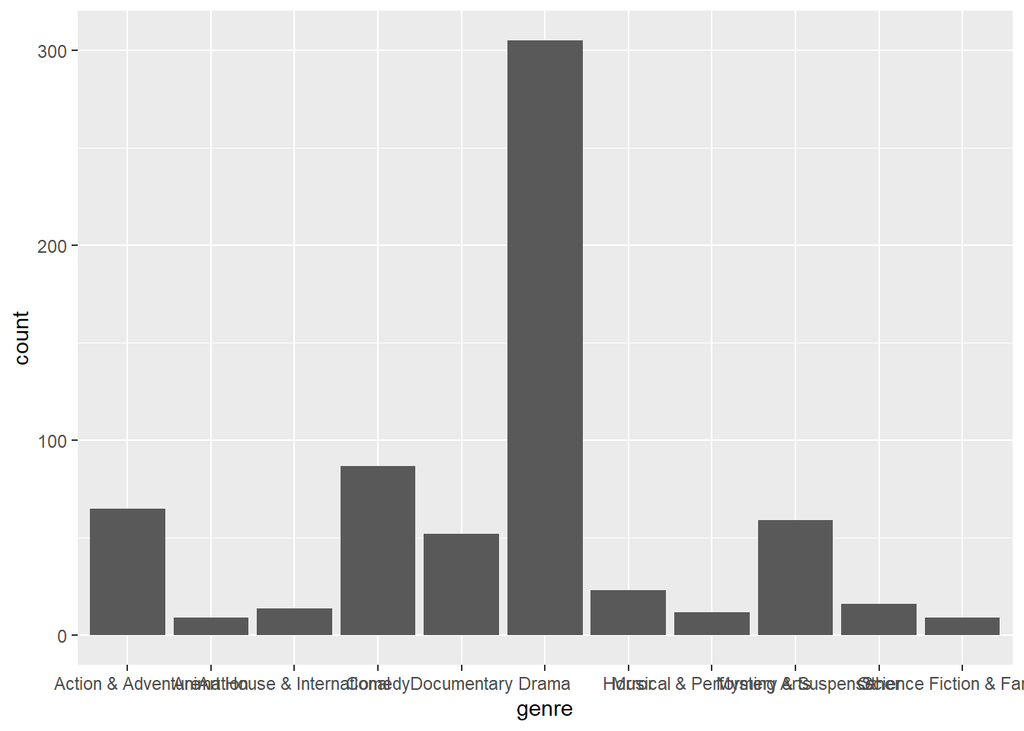

```r
ggplot(movies,aes(x = genre)) + geom_bar()
```

```r
summary(movies$genre)
```

```
##        Action & Adventure                 Animation Art House & International
##                        65                         9                        14
##                    Comedy               Documentary                     Drama
##                        87                        52                       305
##                    Horror Musical & Performing Arts        Mystery & Suspense
##                        23                        12                        59
##                     Other Science Fiction & Fantasy
##                        16                         9
```

```r
305/651
```

```
## [1] 0.46851
```

Interesting results, isn’t it ? It seems like the movie genre is dominated by the Drama(46.85%). Does that mean we are rejecting the random sampling because almost the half of the movies falls into the same category? Before we can be so assertive on that, let’s mine more information out of the data.

## Testing the Generalizability

What else we can look at? Maybe we can look at the releasing year in theater and director who directed the movie. Why are we interested into those variables? The investigation in the year of releasing can help us to determine whether the movise are not random sampled up to date. And for analyzing the directors/actors to avoid that the data were sampled towards to a particular director or an actor.

### Releasing year investigation

Investigate how many movies were released each year up to date and find out if the most productive year of releasing the movies.

```r
#some analysis
table(movies$thtr_rel_year)
```

```
##
## 1970 1972 1973 1974 1975 1976 1977 1978 1979 1980 1981 1982 1983 1984 1985 1986
##    1    3    4    8    5    4   12    7    7   12   11    6    7   10    6   10
## 1987 1988 1989 1990 1991 1992 1993 1994 1995 1996 1997 1998 1999 2000 2001 2002
##   14   13   14   10   15   16   22    9   17   27   13   14   18   18   17   23
## 2003 2004 2005 2006 2007 2008 2009 2010 2011 2012 2013 2014
##   25   28   17   33   33   22   18   21   26   27   19    9
```

```r
max(table(movies$thtr_rel_year))
```

```
## [1] 33
```

```r
nrow(subset(movies, genre == "Drama" & thtr_rel_year == 2006))
```

```
## [1] 19
```

```r
nrow(subset(movies, genre == "Drama" & thtr_rel_year == 2007))
```

```
## [1] 16
```

### Director name or actor name investigation

Similarly, we can proceed to seek for if the observations are based on a particular director or a particular actor.

```r
#The most number of the movies produced by certain director
max(table(movies$director))
```

```
## [1] 4
```

```r
#The most number of the movies have the same actor1 paticipated in.
max(table(movies$actor1))
```

```
## [1] 7
```

```r
#The most number of the movies have the same actor2 paticipated in.
max(table(movies$actor2))
```

```
## [1] 5
```

```r
#The most number of the movies have the same actor3 paticipated in.
max(table(movies$actor3))
```

```
## [1] 3
```

```r
#The most number of the movies have the same actor4 paticipated in.
max(table(movies$actor4))
```

```
## [1] 3
```

```r
#The most number of the movies have the same actor5 paticipated in.
max(table(movies$actor5))
```

```
## [1] 2
```

As we expected, the results of the movies with the most number of actor in and the most number of directors filmed all shows less than 5% of total sample population.

In this case, we can confirm that the movies were random sampled from the all movies from 1970 and up to date. There are more than 10% of the movies are “Drama” just by chance.Or we can see, the Drama movies has been leading the trend over the years.

Yeah, right; who doesn’t like “Drama” around?

### Research Question Variables

Let’s put all the variables that we are going to analysis together and create a new data frame to include all variables in the research qeustions and name is rq_mv.

```r
rq_mv <- movies %>% select(thtr_rel_year,thtr_rel_month,thtr_rel_day,imdb_rating,critics_score,critics_rating)
```

## Part 4: Modeling

We first build our linear regression model

```r
imdb_mlr = lm(imdb_rating~ thtr_rel_year+ thtr_rel_month + thtr_rel_day + critics_score+critics_rating, data = rq_mv)

summary(imdb_mlr)
```

```
##
## Call:
## lm(formula = imdb_rating ~ thtr_rel_year + thtr_rel_month + thtr_rel_day +
##     critics_score + critics_rating, data = rq_mv)
##
## Residuals:
##      Min       1Q   Median       3Q      Max
## -2.83960 -0.41092  0.03377  0.45256  2.54962
##
## Coefficients:
##                        Estimate Std. Error t value Pr(>|t|)
## (Intercept)          -1.0845853  5.1598447  -0.210  0.83358
## thtr_rel_year         0.0026539  0.0025673   1.034  0.30165
## thtr_rel_month        0.0133256  0.0076846   1.734  0.08338 .
## thtr_rel_day         -0.0003368  0.0031131  -0.108  0.91387
## critics_score         0.0354626  0.0020241  17.520  < 2e-16 ***
## critics_ratingFresh  -0.0827307  0.0818564  -1.011  0.31255
## critics_ratingRotten  0.3627702  0.1338779   2.710  0.00691 **
## ---
## Signif. codes:  0 '***' 0.001 '**' 0.01 '*' 0.05 '.' 0.1 ' ' 1
##
## Residual standard error: 0.6902 on 644 degrees of freedom
## Multiple R-squared:  0.5989, Adjusted R-squared:  0.5952
## F-statistic: 160.3 on 6 and 644 DF,  p-value: < 2.2e-16
```

We can also do ANOVA on the model we built to test the independece of each variable to the other.

```r
Anova_results <- aov(imdb_mlr)

summary(Anova_results)
```

```
##                 Df Sum Sq Mean Sq F value  Pr(>F)
## thtr_rel_year    1    0.7     0.7   1.445 0.22971
## thtr_rel_month   1    4.0     4.0   8.385 0.00391 **
## thtr_rel_day     1    0.2     0.2   0.460 0.49792
## critics_score    1  445.2   445.2 934.732 < 2e-16 ***
## critics_rating   2    7.9     4.0   8.322 0.00027 ***
## Residuals      644  306.8     0.5
## ---
## Signif. codes:  0 '***' 0.001 '**' 0.01 '*' 0.05 '.' 0.1 ' ' 1
```

A paired plot could tell us more information on the multi-linearity of the research data set. In the paired plot below, we plot all 6 variables in cluding “imdb_rating”, “thtr_rel_year”, “thtr_rel_month”, “thtr_rel_day”, “critics_score”,“critics_rating” and filled the color with a categorical variables “critics_rating”.

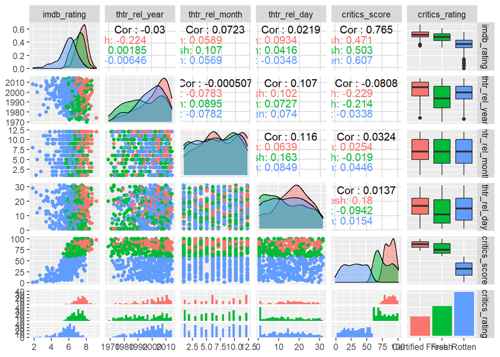

```r
rq_mv %>% ggpairs(columns = c("imdb_rating", "thtr_rel_year", "thtr_rel_month", "thtr_rel_day", "critics_score","critics_rating"),aes(color = critics_rating),diag = list(continuous= wrap("densityDiag",alpha=0.5)))
```

The paired plot showed us the linearities among the variables. The correlation between critics_score and the imdb_rating have highest correlation. Which makes sense that the critics and the imdb rating of the movies are associated with each other.

## Part 5: Prediction

In building the prediction model, we are expecting to find the parsimonius model, which means the simpliest model with highest power predictor. In the other words, we need to find what does the imdb score mostly correlated to, so we have to drop the 6 variables down to the least number of variables but yield the highest prediction power.

### Stepwise Model Selection

There are several methods we could utilize to find the best fit model. Two famous methose are forward selection and back eliminations. Since we only have 6 variables in our research data set, we can use the backward elimination to drop one predictor at a time until we reach our parsimonious model.

#### Back Elimination: Step 1

Let’s review our full multi-linear regression modle as we did in the previous section.

```r
summary(imdb_mlr)
```

```
##
## Call:
## lm(formula = imdb_rating ~ thtr_rel_year + thtr_rel_month + thtr_rel_day +
##     critics_score + critics_rating, data = rq_mv)
##
## Residuals:
##      Min       1Q   Median       3Q      Max
## -2.83960 -0.41092  0.03377  0.45256  2.54962
##
## Coefficients:
##                        Estimate Std. Error t value Pr(>|t|)
## (Intercept)          -1.0845853  5.1598447  -0.210  0.83358
## thtr_rel_year         0.0026539  0.0025673   1.034  0.30165
## thtr_rel_month        0.0133256  0.0076846   1.734  0.08338 .
## thtr_rel_day         -0.0003368  0.0031131  -0.108  0.91387
## critics_score         0.0354626  0.0020241  17.520  < 2e-16 ***
## critics_ratingFresh  -0.0827307  0.0818564  -1.011  0.31255
## critics_ratingRotten  0.3627702  0.1338779   2.710  0.00691 **
## ---
## Signif. codes:  0 '***' 0.001 '**' 0.01 '*' 0.05 '.' 0.1 ' ' 1
##
## Residual standard error: 0.6902 on 644 degrees of freedom
## Multiple R-squared:  0.5989, Adjusted R-squared:  0.5952
## F-statistic: 160.3 on 6 and 644 DF,  p-value: < 2.2e-16
```

Since the R squared value will always positively associated with the number of the variables, to focus on the R squared value to reach our best fit model seems impossible. In this case, we will look at two criteria: the p-value and adjusted R^2 to reach the maximum adjusted R-squared.

start looking at p-values, the “thrt_rel_day” stands out by its high p-value at 0.91387, remember that the lowerst the p-value, the more significant of the variable is.

```r
#eliminate the "thrt_rel_day"
summary(lm(formula = imdb_rating ~
             thtr_rel_year + thtr_rel_month +
    critics_score + critics_rating, data = rq_mv))
```

```
##
## Call:
## lm(formula = imdb_rating ~ thtr_rel_year + thtr_rel_month + critics_score +
##     critics_rating, data = rq_mv)
##
## Residuals:
##      Min       1Q   Median       3Q      Max
## -2.84420 -0.41129  0.03063  0.45424  2.54671
##
## Coefficients:
##                       Estimate Std. Error t value Pr(>|t|)
## (Intercept)          -1.044924   5.142864  -0.203  0.83906
## thtr_rel_year         0.002632   0.002557   1.029  0.30379
## thtr_rel_month        0.013235   0.007633   1.734  0.08340 .
## critics_score         0.035462   0.002023  17.533  < 2e-16 ***
## critics_ratingFresh  -0.081793   0.081334  -1.006  0.31496
## critics_ratingRotten  0.363323   0.133678   2.718  0.00675 **
## ---
## Signif. codes:  0 '***' 0.001 '**' 0.01 '*' 0.05 '.' 0.1 ' ' 1
##
## Residual standard error: 0.6896 on 645 degrees of freedom
## Multiple R-squared:  0.5989, Adjusted R-squared:  0.5958
## F-statistic: 192.6 on 5 and 645 DF,  p-value: < 2.2e-16
```

Seems like our adjusted R-squared increases from 0.5952 to 0.5958, it didn’t vary too much on the adjusted R-squared. Let’s move on to remove different variable instead of the thtr_rel_day to confirm that the p-value is the key criteria we can use to eleimante less significant predictor to increase our model.

It is tideous to run several times on the model to finde the best correlation. Here is the list of adjusted R-squared values that corresponds to eliminated variables “thtr_rel_year”, “thtr_rel_month”, “critics_score”,“critics_rating” are 0.5951, 0.5939, 0.4032, 0.586.

### Dropping Categorical Variable?

Remember that the “critics_rating” is a categorical variable and has three sub-variables: “rotten”, “fresh”, “certified fresh”. The categorical variable cannot be dropped separately, they must be kept or dropped at the same time. Recap that the critics_ratingRotten yields a 0.00691 in the original analysis, hence having some significance in the model, so we could decide to keep the categorical at first and eliminate as we run different elimination step if necessary.

#### Back Elimination: Step 2

```r
 summary(lm(formula = imdb_rating ~  thtr_rel_month  +
     critics_score + critics_rating, data = rq_mv))
```

```
##
## Call:
## lm(formula = imdb_rating ~ thtr_rel_month + critics_score + critics_rating,
##     data = rq_mv)
##
## Residuals:
##      Min       1Q   Median       3Q      Max
## -2.82679 -0.40258  0.04241  0.43837  2.55441
##
## Coefficients:
##                       Estimate Std. Error t value Pr(>|t|)
## (Intercept)           4.244268   0.191309  22.185  < 2e-16 ***
## thtr_rel_month        0.013127   0.007632   1.720  0.08593 .
## critics_score         0.035224   0.002009  17.529  < 2e-16 ***
## critics_ratingFresh  -0.103072   0.078666  -1.310  0.19057
## critics_ratingRotten  0.342282   0.132111   2.591  0.00979 **
## ---
## Signif. codes:  0 '***' 0.001 '**' 0.01 '*' 0.05 '.' 0.1 ' ' 1
##
## Residual standard error: 0.6897 on 646 degrees of freedom
## Multiple R-squared:  0.5983, Adjusted R-squared:  0.5958
## F-statistic: 240.5 on 4 and 646 DF,  p-value: < 2.2e-16
```

After the elimination the “thtr_rel_year” variable, the adjusted R-squared value did not change at all while eliminating other variables will result in a decrease in adjusted R-squared. Should we eliminated it even there is no change?

The answer is yes, becase the definition or the parsimonious model is to have simplest model with high power predictor. Adding one more variables would add more complexity to the model, hence we drop the variable at this point.

The final prediction model only contains “thtr_rel_month”, “critics_score”, “critics_rating”. The summary of the model is shown in the above R chunk.

The prediction model is created as follow

```r
m_imdb_mlr <- lm(formula = imdb_rating ~  thtr_rel_month  +
     critics_score + critics_rating, data = rq_mv)
```

### Testing the Prediction Model

Let’s create a new data frame with “critics_rating” as Rotten, “thtr_rel_month” as may(5) and the “critics_score” as 32.

```r
new_imdb <- data.frame(critics_rating = "Rotten", thtr_rel_month = 5, critics_score = 32)
```

then we predict the new imdb score using predict function

```r
predict(m_imdb_mlr,new_imdb)
```

```
##        1
## 5.779357
```

## Part 6: Conclusion

To conclude the linear regression and modeling project. The objective is to predict the imdb score of a movie that based on 6 variables were taken from the original data set. There variables are “imdb_rating”, “thtr_rel_year”, “thtr_rel_month”, “thtr_rel_day”, “critics_score”,“critics_rating”.

Then the backward elimination method was utilized to reach parsimonious model which contains three variables “critics_rating”, “thtr_rel_month” and the “critics_score”.